# 460 Model_RandomForest

Geyi Liu

2021/1/10

Introduction: https://corporatefinanceinstitute.com/resources/knowledge/other/random-forest/ https://pubs.acs.org/doi/10.1021/ci034160g

The essence of random forest algorithm is classifier ensemble algorithm based on decision tree. Compared with neural network, random forest reduces the amount of computation and improves the prediction accuracy. Moreover, the algorithm is insensitive to collinearity and robust to missing data and unbalanced data, which can be well adapted to thousands of explanatory variable data sets.

```r
library(pROC) # Draw ROC curve
library(randomForest)
library(stringr)
library(dplyr)
data <- read.csv("Data.csv", stringsAsFactors=FALSE)
data$LAB <- as.factor(data$LAB) # convert LAB to be a factor
data[is.na(data)] <- 0 # replace NAs with zero
data_model <- data
data_model$X <- NULL # drop identifier column
data_model$LAB <- NULL # drop non-numeric LAB column
data_model <- data_model[1:nrow(data_model),477:ncol(data_model)]
```

```r
a=ncol(data_model) # number of columns
b=nrow(data_model)*0.8 # 80% number of rows
c=c()
# Delete columns with more than 80% zeros
for(i in 1:a){
  # print(sum(data_model[,i]==0)) # Number of 0 per column
  if( sum(data_model[,i]==0)>=b ){
    c=append(c,i)
  }
  }
print(c) # Columns to be deleted
```

```
##   [1]   1   3   4   5  10  12  14  15  16  17  18  19  21  22  23  24  25  26
##  [19]  27  28  38  47  48  55  62  65  66  67  69  71  72  77  78  79  80  82
##  [37]  83  87  93  94  96  97  98  99 100 101 102 103 104 105 106 107 108 109
##  [55] 110 111 112 114 116 117 118 119 122 123 124 125 126 127 128 129 130 132
##  [73] 133 135 136 137 138 139 140 141 142 143 144 145 146 147 148 149 150 151
##  [91] 152 153 154 155 156 157 158 160 163 164 165 166 167 168 169 170 171 172
## [109] 173 174 175 176 177 178 180 183 186 187 188 189 190 191 192 193 194 207
## [127] 210 213 214 215 216 217 218 219 220 221 222 230 231 232 233 234 235 236
## [145] 237 238 239 240 241 242 243 244 245 246 247 248 249 250 251 252 261 262
## [163] 267 269 323 324 325 327 332
```

```r
Data_remove=data_model[,-c]
Data_remove$Pass = as.numeric(Data_remove$Response >= 50)
Data_remove$Pass <- as.factor(Data_remove$Pass)
# Replace Response with Pass
Data_remove <- subset(Data_remove, select = -c(Response))
```

```r
set.seed(100)
# Divide the data set  into training set and test set, the ratio is 7:3
train_sub = sample(nrow(Data_remove),7/10*nrow(Data_remove))
train_data = Data_remove[train_sub,]
test_data = Data_remove[-train_sub,]
```

# Some important parameters of randomForest()

ntree: the number of trees in the forest. The default is 500 mtry: number of features used per tree Importance: whether to calculate theimportance of variables. The default value is false Proximity: whether to calculate the similarity between observations

```r
# There are many variables, so the operation time will be long
set.seed(100)
rf <- randomForest(Pass ~ ., data=train_data,importance=TRUE, proximity=TRUE,type=classification)
print(rf)
```

```
##
## Call:
##  randomForest(formula = Pass ~ ., data = train_data, importance = TRUE,      proximity = TRUE, type = classification)
##                Type of random forest: classification
##                      Number of trees: 500
## No. of variables tried at each split: 12
##
##         OOB estimate of  error rate: 9.64%
## Confusion matrix:
##      0   1 class.error
## 0 3516 118  0.03247111
## 1  311 507  0.38019560
```

```r
print(rf)
```

```
##
## Call:
##  randomForest(formula = Pass ~ ., data = train_data, importance = TRUE,      proximity = TRUE, type = classification)
##                Type of random forest: classification
##                      Number of trees: 500
## No. of variables tried at each split: 12
##
##         OOB estimate of  error rate: 9.64%
## Confusion matrix:
##      0   1 class.error
## 0 3516 118  0.03247111
## 1  311 507  0.38019560
```

```r
TP<-rf$confusion[4]
TN<-rf$confusion[1]
FN<-rf$confusion[2]
FP<-rf$confusion[3]
print(FP)
```

```
## [1] 118
```

```r
# Recall
Rec <-TP/(TP+FN)
# Precision
Pre<-TP/(TP+FP)
# Accuracy
Acc<-(TP+TN)/(TP+FN+TN+FP)
# F1 score
F1 <- 2*Acc*Rec/(Acc+Rec)
```

View the importance of variables: Mean decrease accuracy: the decrease of accuracy after replacing this variable. Mean decrease Gini: the decrease of Gini coefficient after variable replacement. The larger the value, the more important the variable is.

```r
# importance()
imp= as.data.frame(rf$importance)
# Check which variables are important
best <- subset(imp,imp$MeanDecreaseGini>10)
```

Group1_11,Group1_9,Group1_2 are the most important factors that affect whether the product passes the test.

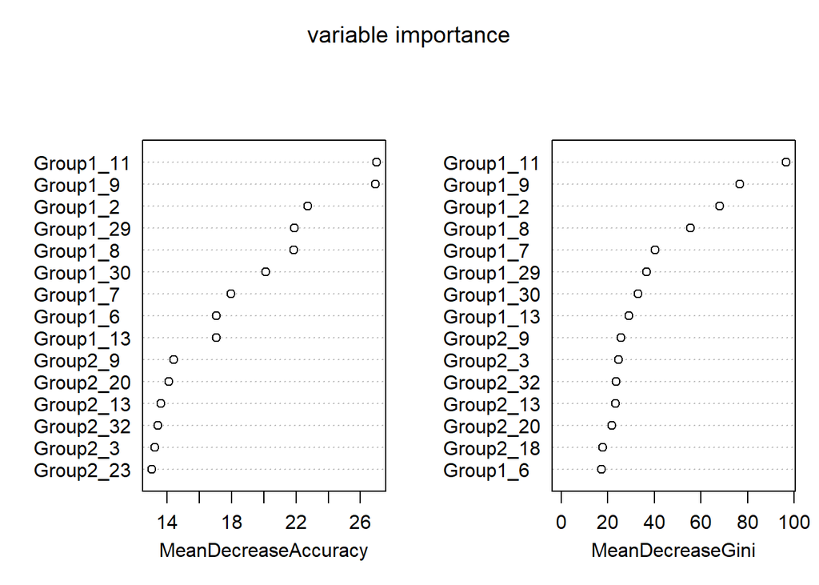

```r
# Output the top 15 important variables
varImpPlot(rf, main = "variable importance",n.var=15)
```

```r
# Predicting the test sets
pre_ran <- predict(rf,newdata=test_data)
# Integrating real and predicted values
obs_p_ran = data.frame(prob=pre_ran,obs=test_data$Pass)
# Output confusion matrix
table(test_data$Pass,pre_ran,dnn=c("Real","Predict"))
```

```
##     Predict
## Real    0    1
##    0 1490   42
##    1  130  246
```

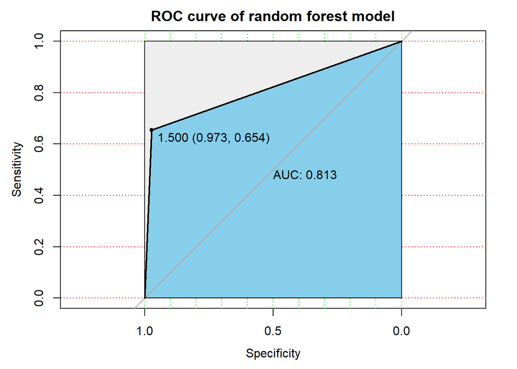

```r
# Draw ROC curve
ran_roc <- roc(test_data$Pass,as.numeric(pre_ran))
plot(ran_roc, print.auc=TRUE, auc.polygon=TRUE, grid=c(0.1, 0.2),grid.col=c("green", "red"), max.auc.polygon=TRUE,auc.polygon.col="skyblue", print.thres=TRUE,main='ROC curve of random forest model')
```

```r
pred_out_1<-predict(object=rf,newdata=test_data,type="prob")
table <- table(test_data$Pass,pre_ran)
print(table)
```

```
##    pre_ran
##        0    1
##   0 1490   42
##   1  130  246
```

```r
# diag(table): Extract the values on the diagonal of the matrix
sum(diag(table))/sum(table)  # Prediction accuracy
```

```
## [1] 0.9098532
```

AUC（Area Under Curve: ) is used to indicate the accuracy of prediction. The higher the AUC (the larger the area under the curve), the higher the accuracy of prediction.

The most important variables obtained by the random forest model are inconsistent with those obtained by the linear regression model. Classification model and linear regression model have different results because of their different principles.

The results of random forest can be compared with the results of other classification models.